# Netflix: Content Trends by Country

22761926

2026-06-18

# Overview

- We compared Netflix movie content across six countries: United States, India, United Kingdom, Spain, Nigeria and Japan.
- We looked at movie length, content maturity ratings, common themes in movie descriptions, and audience scores.
- As a bonus, we compared genre popularity between Netflix and HBO, reusing the HBO dataset from Question 2.

# Movie Length by Country

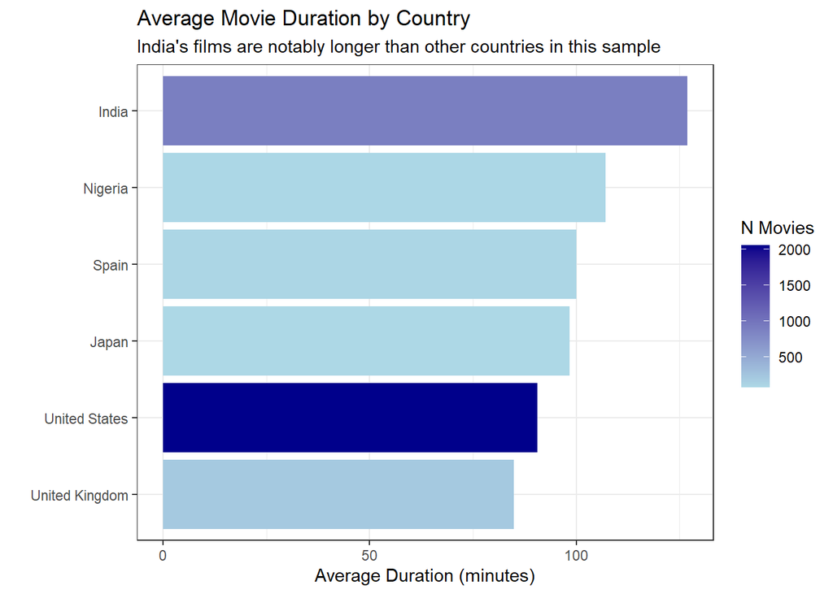

- India’s films average 127 minutes, notably longer than every other country in this sample.
- This fits with the well-known convention of longer Bollywood runtimes, which often include multiple storylines and musical sequences.
- The United Kingdom has the shortest average runtime at 85 minutes, followed closely by the United States.
- Most countries cluster fairly close together, between 85 and 110 minutes, with India as the clear outlier.

# Content Maturity by Country

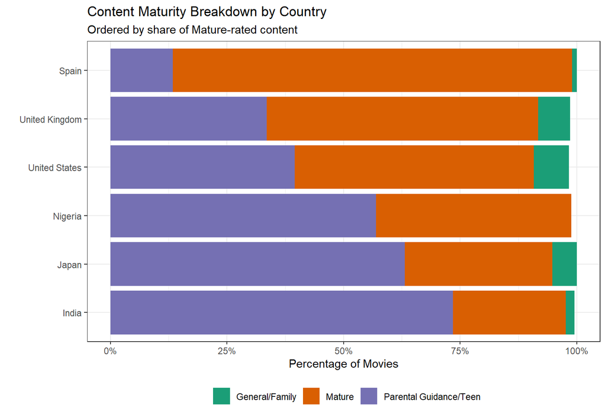

- Spain’s content skews heavily toward Mature ratings, at nearly 86%, the highest of any country in this sample.
- India sits at the opposite end. Mature content makes up only 24% of its movies, with Parental Guidance/Teen content dominating at 74%.
- The United States and United Kingdom sit roughly in the middle, both with Mature content making up around half of their movies.
- General/Family content is a small share everywhere, never exceeding 8% in any country.

# Movie Themes by Country

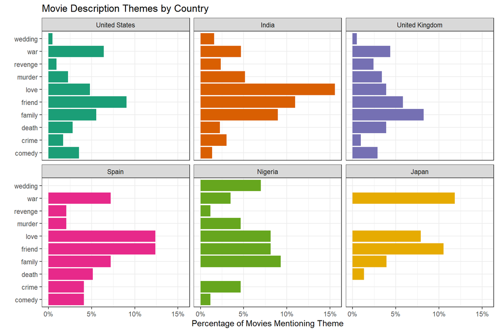

# Movie Ratings by Country

[figure not shown]

# Bonus: Comparing Netflix and HBO Genre Mix

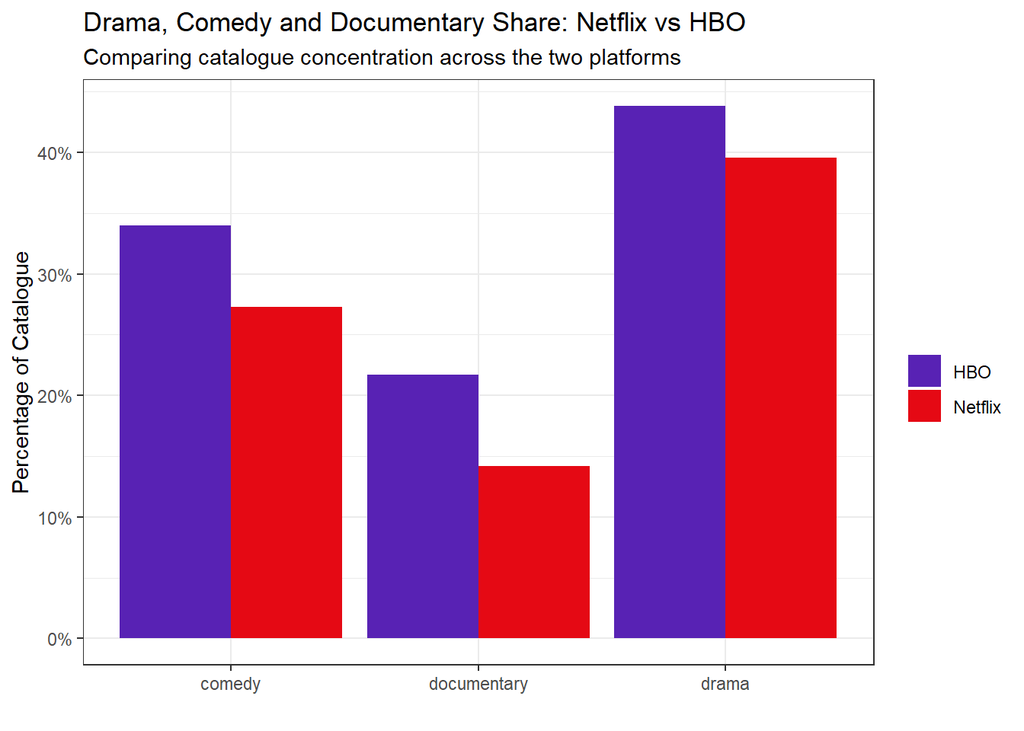

- HBO’s catalogue is more concentrated than Netflix’s across all three genres compared here.
- Drama is the largest category on both platforms, making up 43.8% of HBO’s catalogue and 39.6% of Netflix’s.
- Comedy and documentary follow the same pattern, with HBO’s share exceeding Netflix’s in both cases.
- This comparison was limited to drama, comedy and documentary, the genres with clearly comparable naming once pluralization and terminology differences between the two platforms were resolved. A full genre-by-genre comparison would require reconciling many more inconsistently named categories.